# Topic 1 Exercises

## 2.4.9

### A

```r
data(Auto, package = "ISLR")
auto = na.omit(Auto)
head(auto)
```

```
##   mpg cylinders displacement horsepower weight acceleration year origin
## 1  18         8          307        130   3504         12.0   70      1
## 2  15         8          350        165   3693         11.5   70      1
## 3  18         8          318        150   3436         11.0   70      1
## 4  16         8          304        150   3433         12.0   70      1
## 5  17         8          302        140   3449         10.5   70      1
## 6  15         8          429        198   4341         10.0   70      1
##                        name
## 1 chevrolet chevelle malibu
## 2         buick skylark 320
## 3        plymouth satellite
## 4             amc rebel sst
## 5               ford torino
## 6          ford galaxie 500
```

mpg, cylinders, displacement, horsepower, weight, and acceleration are quantitative. year, origin, and name are qualitative.

### B

```r
range(auto$mpg)
```

```
## [1]  9.0 46.6
```

```r
range(auto$cylinders)
```

```
## [1] 3 8
```

```r
range(auto$displacement)
```

```
## [1]  68 455
```

```r
range(auto$horsepower)
```

```
## [1]  46 230
```

```r
range(auto$weight)
```

```
## [1] 1613 5140
```

```r
range(auto$acceleration)
```

```
## [1]  8.0 24.8
```

### C

```r
summary(auto)
```

```
##       mpg          cylinders      displacement     horsepower
##  Min.   : 9.00   Min.   :3.000   Min.   : 68.0   Min.   : 46.0
##  1st Qu.:17.00   1st Qu.:4.000   1st Qu.:105.0   1st Qu.: 75.0
##  Median :22.75   Median :4.000   Median :151.0   Median : 93.5
##  Mean   :23.45   Mean   :5.472   Mean   :194.4   Mean   :104.5
##  3rd Qu.:29.00   3rd Qu.:8.000   3rd Qu.:275.8   3rd Qu.:126.0
##  Max.   :46.60   Max.   :8.000   Max.   :455.0   Max.   :230.0
##
##      weight      acceleration        year           origin
##  Min.   :1613   Min.   : 8.00   Min.   :70.00   Min.   :1.000
##  1st Qu.:2225   1st Qu.:13.78   1st Qu.:73.00   1st Qu.:1.000
##  Median :2804   Median :15.50   Median :76.00   Median :1.000
##  Mean   :2978   Mean   :15.54   Mean   :75.98   Mean   :1.577
##  3rd Qu.:3615   3rd Qu.:17.02   3rd Qu.:79.00   3rd Qu.:2.000
##  Max.   :5140   Max.   :24.80   Max.   :82.00   Max.   :3.000
##
##                  name
##  amc matador       :  5
##  ford pinto        :  5
##  toyota corolla    :  5
##  amc gremlin       :  4
##  amc hornet        :  4
##  chevrolet chevette:  4
##  (Other)           :365
```

### D

```r
dim(auto)
```

```
## [1] 392   9
```

```r
autoSubset = auto[-c(10:85),]
dim(autoSubset)
```

```
## [1] 316   9
```

```r
summary(autoSubset)
```

```
##       mpg          cylinders      displacement     horsepower
##  Min.   :11.00   Min.   :3.000   Min.   : 68.0   Min.   : 46.0
##  1st Qu.:18.00   1st Qu.:4.000   1st Qu.:100.2   1st Qu.: 75.0
##  Median :23.95   Median :4.000   Median :145.5   Median : 90.0
##  Mean   :24.40   Mean   :5.373   Mean   :187.2   Mean   :100.7
##  3rd Qu.:30.55   3rd Qu.:6.000   3rd Qu.:250.0   3rd Qu.:115.0
##  Max.   :46.60   Max.   :8.000   Max.   :455.0   Max.   :230.0
##
##      weight      acceleration        year           origin
##  Min.   :1649   Min.   : 8.50   Min.   :70.00   Min.   :1.000
##  1st Qu.:2214   1st Qu.:14.00   1st Qu.:75.00   1st Qu.:1.000
##  Median :2792   Median :15.50   Median :77.00   Median :1.000
##  Mean   :2936   Mean   :15.73   Mean   :77.15   Mean   :1.601
##  3rd Qu.:3508   3rd Qu.:17.30   3rd Qu.:80.00   3rd Qu.:2.000
##  Max.   :4997   Max.   :24.80   Max.   :82.00   Max.   :3.000
##
##                         name
##  ford pinto               :  5
##  toyota corolla           :  5
##  amc matador              :  4
##  chevrolet chevette       :  4
##  amc hornet               :  3
##  chevrolet caprice classic:  3
##  (Other)                  :292
```

### E

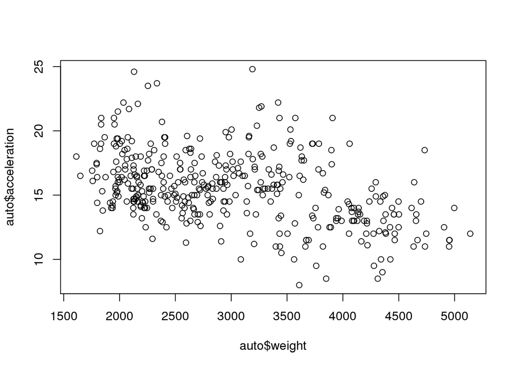

```r
# First I explored whether there's a relationship between the weight of a car and how fast it accelerates. There seems to be a vague trend of higher weight correlating to lower acceleration. But it is an undefined trend and would need more modeling.
plot(auto$weight, auto$acceleration)
```

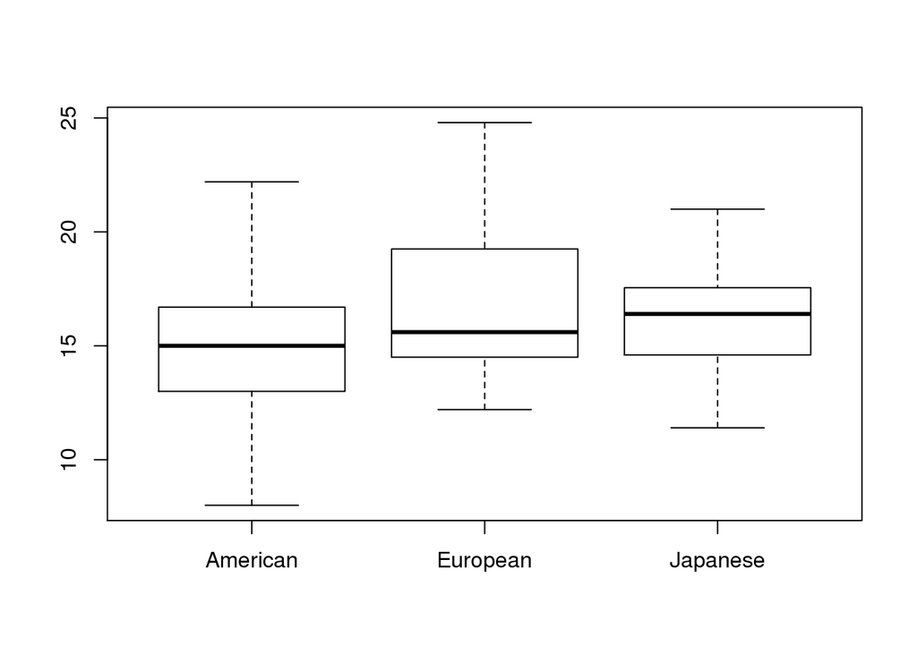

```r
# Next I explored whether the country of origin is related to acceleration, first releveling the "origin" variable so that 1, 2, 3 were named. From this we can see that Japanese-made cars have slightly higher median acceleration, and American-made cars have the widest range in acceleration, and European cars have the highest acceleration of all (though their median is lower than Japanese-made).
auto$origin=factor(auto$origin, labels=c("American", "European", "Japanese"))
plot(auto$origin, auto$acceleration)
```

### F

I didn’t graph anything against mpg, but I imagine there would be a relationship between weight and mpg, with bigger, heavier cars having a lower mpg. A quick look at a plot shows us:

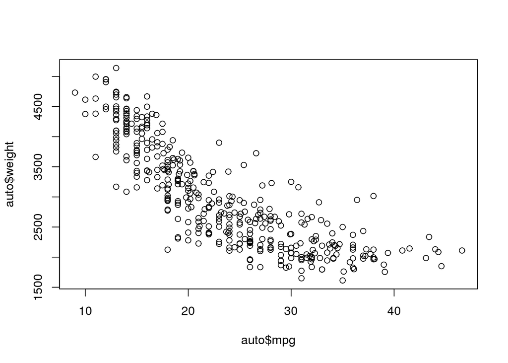

```r
plot(auto$mpg, auto$weight)
```

There does indeed appear to be a relationship, perhaps a logarithmic one. I think year would probably also have an effect: older cars may be less likely to be fuel-efficient.

## 2.4.2

### A

This is a regression problem because we are looking at what affects CEO salary, a quantitative variable. We are most interested in inference, because we want to be able to interpret what effect each factor has on CEO salary; we’re not predicting salaries. n = 500 p = profit, # of employees, industry

### B

This is a classification problem because we are looking at a yes/no response variable–there are only two options. We are most interested in prediction, because we want to know how another similar product might perform in the future. n = 20 p = price for product, marketing budget, competition price, 10 others

### C

This is a regression problem because we are looking at % change, a quantitative variable. And we are most interested in prediction, because we want to know how the USD will fluctuate in the future. n = 52 (weeks per year) p = % change in US market, % change in Brit market, % change in German market

## 2.4.7

### A

```r
obs1 = sqrt(((0-0)^2) + ((0-3)^2) + ((0-0)^2))
obs2 = sqrt(((0-2)^2) + ((0-0)^2) + ((0-0)^2))
obs3 = sqrt(((0-0)^2) + ((0-1)^2) + ((0-3)^2))
obs4 = sqrt(((0-0)^2) + ((0-1)^2) + ((0-2)^2))
obs5 = sqrt(((0+1)^2) + ((0-0)^2) + ((0-1)^2))
obs6 = sqrt(((0-1)^2) + ((0-1)^2) + ((0-1)^2))

euclidDist = c(obs1, obs2, obs3, obs4, obs5, obs6)
euclidDist
```

```
## [1] 3.000000 2.000000 3.162278 2.236068 1.414214 1.732051
```

### B

The smallest Euclidean distance is for observation #5: therefore, we predict (0, 0, 0), our Y point, will be Green, same as observation #5.

### C

The three smallest distances are for observations #2, #5, and #6. #2 and #6 are Red while #5 is Green. Therefore, we predict our Y point will be Red, like 2/3 nearest points.

### D

We would expect the best value of K to be small, because a small value for K makes the boundary more flexible and more likely to be non-linear. However, if K is too small, we run the risk of overfitting.